# WP2 meeting 10th November 2026

Predicting type 2 diabetes after childbirth: protocol and preliminary findings

Jonas R. Schaarup

Steno Diabetes Center Aarhus

Elpida Vounzoulaki

Steno Diabetes Center Aarhus

Hjalte Mikkelsen

Steno Diabetes Center Copenhagen

## Aim for today

- Present and get feedback on current protocol
- Present some preliminary findings
- Discuss how to present our work to WP4 (intervention team)

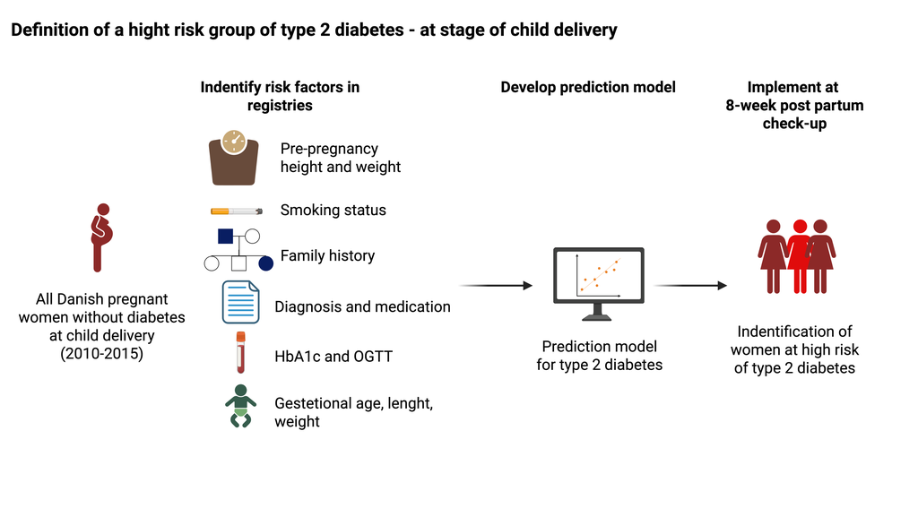

Prediction project to identify women at high risk of type 2 diabetes

## Aim

Develop and validate a prediction model that identifies women at **high risk of type 2 diabetes** after giving birth

**Long-term goal:** a clinically ready tool at the **8-week postpartum check-up** in general practice, so that high-risk women can be offered the intervention designed in **WP4**

# Methods

Definition of population

## Study population

**Women who:**

- gave birth at least once between **2010 and 2015**
- have no previous diagnosis of type 1 or type 2 diabetes at the index date
- age at delivery between 18-49 years

**Exclusion:**

- Stillbirth in primiparous women (parity = 1)

## Time window for prediction

**Exploration**  
2003-2009

**Training**  
2010-2014

**Test**  
2015

**Prediction horizon**  
2016-2025

- **Index date:** one week after delivery, so that all delivery data are registered
- **Outcome:** 10-year risk of registry-defined type 2 diabetes (follow-up to 31 Dec 2025)
- **Censoring:** emigration, death or end of follow-up

## Predictors at index date

### Before, during and at delivery

| Pre-pregnancy | During pregnancy | At delivery |
| --- | --- | --- |
| **Demographics** age, origin, education, income | **BMI** first antenatal visit | **Gestational age** preterm, spontaneous or induced |
| **Diagnoses** all ICD-10, 10 years before | **Smoking** first antenatal visit | **Newborn size** weight, length, macrosomia |
| **Specific diagnoses** PMOS, previous GDM, pre-eclampsia | **OGTT** performed; values below threshold | **Size for gestational age** SGA, LGA by sex |
| **Medication** all ATC, 10 years before | **HbA1c** early pregnancy | **Mode of delivery** vaginal, planned or emergency CS |
| **Laboratory** HbA1c, lipids, liver, kidney, CRP | **Gestational diabetes** early (< wk 20) or late (> wk 28) | **Complications** abruption, neonatal hypoglycaemia |
| **Family history** T2D and GDM in relatives | **Hypertensive disorders** pre-eclampsia or GH; early or late | **Plurality** singleton or multiple |

## Cohort and subcohorts for prediction model

### Main model and partial data

**Full cohort**

All nationwide predictors for every index birth, **except laboratory measurements**

**Subcohorts** by partly available data

## Finding potential predictors in the exploration data

Exploration data: deliveries **2003-2009**, kept apart from model development

**1. Screen**  
Test every ICD-10 and ATC code (10-year history) against 10-year T2D risk. Manhattan plot by code group

**2. Expert review**  
SDCA and SDCC experts: is the signal biased? Collapse overlapping predictors (hypertension + antihypertensives)

**3. Prevalence vs effect**  
10-year risk given each remaining variable; plot prevalence against strength of association

**4. Expert review**  
Keep relevant predictors given prevalence and magnitude of risk

## Model choice

### Choosing the statistical model and predictors

- The exploration data (2003-2009) go to the **team of prediction modellers**, who compete for the best performing model in terms of:
  - 1. choice of statistical / ML method
  - 2. included predictors
  - 3. handling of predictors (splines, interaction, penalization)
- Some candidate methods: **Cox**, **Poisson**, **LASSO**, **random forest**
- Combined in a **super learner** that picks the best model by cross-validated **Brier score**

## Partial data

### HbA1c availability

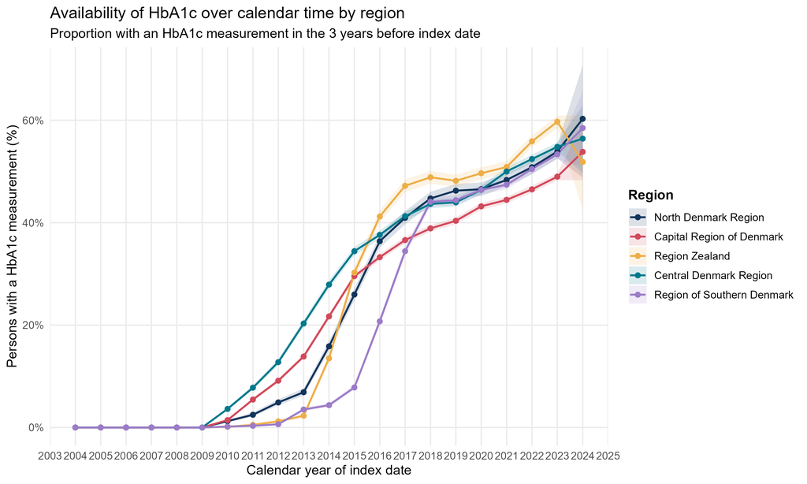

## Handling partly available markers

**Developed in the full cohort**

1. Marker as a present/absent indicator, together with calendar time
2. Multiple imputation of markers available at baseline

**Developed in the subcohort**

3. Submodel restricted to complete cases

## Validation

### Geographical and temporal test sets

**Geographical**

Leave one region out of development and test there

**Temporal**

Test on **2015** deliveries, closest to the 2027 population where the model will be used

**Performance:** Brier score, to emphasise individual calibration of risk

**Subgroups:** age group, parity, HbA1c present or absent at baseline

# Preliminary findings

## Descriptive

## Trends in incidence of type 2 diabetes

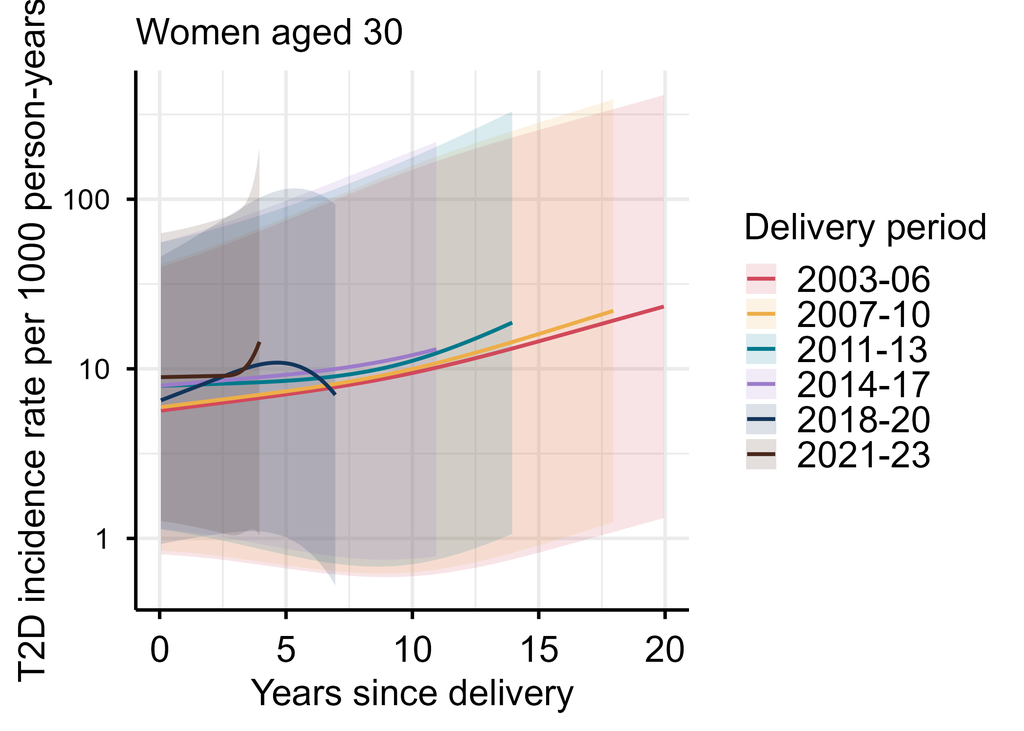

Incidence trends of type 2 diabetes by period

## Trends in incidence type 2 diabetes by region

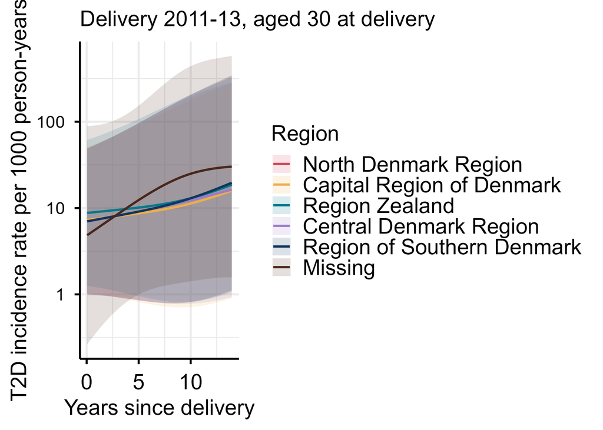

Incidence trends of type 2 diabetes by region

## The usual suspects as predictors

## Body mass index

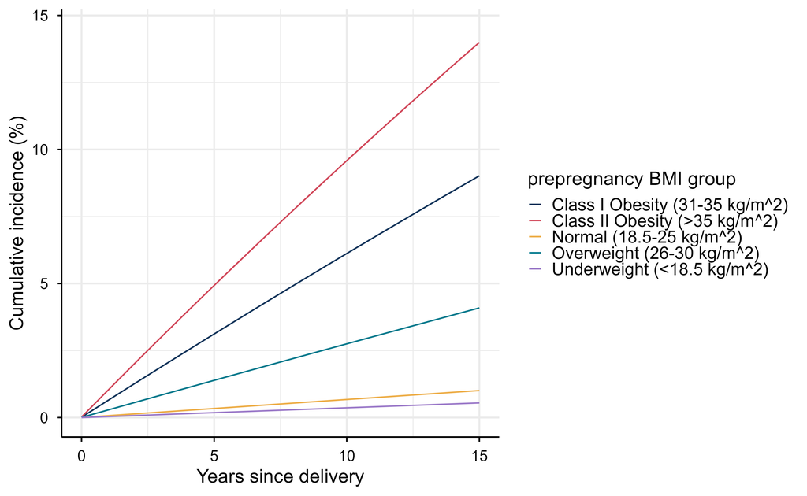

## Trends in BMI distribution over calendar and by region

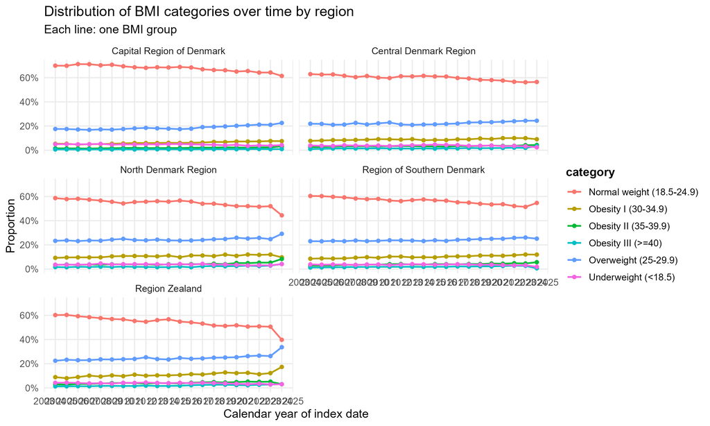

BMI distribtion

## Education

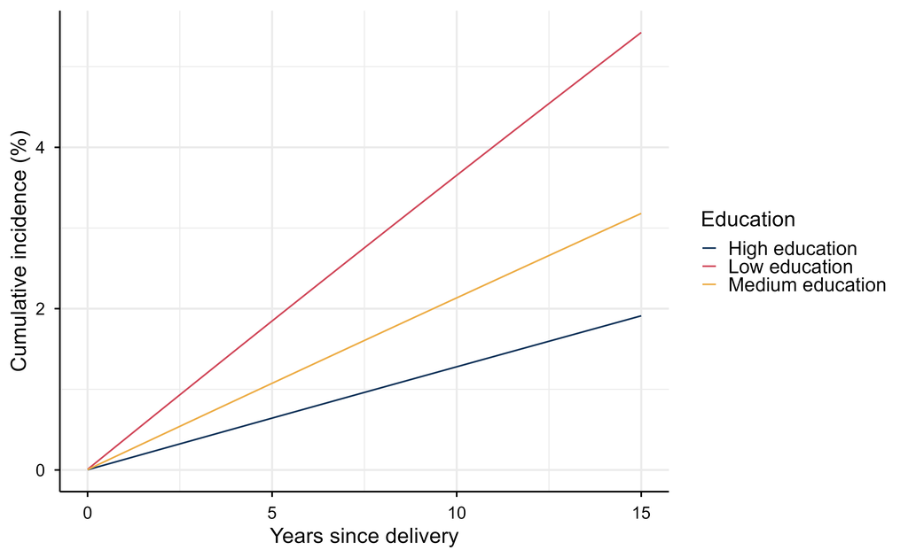

Cummulative incidence of type 2 diabetes

## Ethnicity

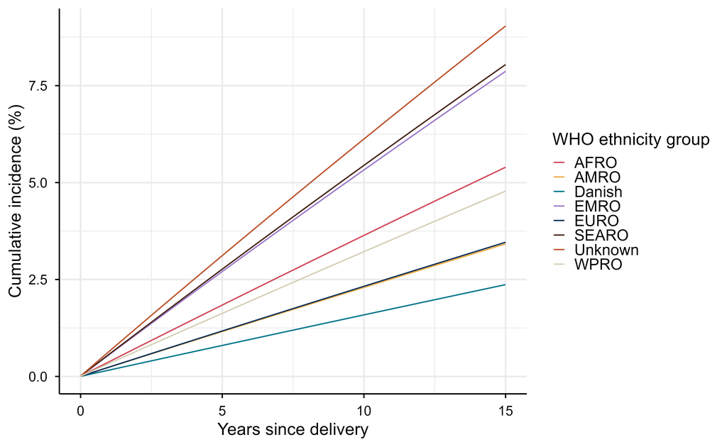

Cummulative incidence trends of type 2 diabetes by ethnicity

## Trends in smoking distribution over calendar and by region

[figure not shown]

Smoking distribtion

## Population development data

### Development data, mean (SD) or n (%)

| Characteristic | N = 253,507 | Missing |
| --- | --- | --- |
| Age, years | 30.8 (5.1) | 0 (0%) |
| Region of origin (WHO) |  | 0 (0%) |
| Danish | 209,875 (83%) |  |
| AFRO | 1,725 (0.7%) |  |
| AMRO | 1,564 (0.6%) |  |
| EMRO | 11,154 (4.4%) |  |
| EURO | 22,692 (9.0%) |  |
| SEARO | 2,782 (1.1%) |  |
| WPRO | 3,565 (1.4%) |  |
| Unknown | 150 (<0.1%) |  |
| Education |  | 64,877 (26%) |
| Low education | 23,581 (13%) |  |
| Medium education | 59,946 (32%) |  |
| High education | 105,103 (56%) |  |

| Characteristic | N = 253,507 | Missing |
| --- | --- | --- |
| Income quartile |  | 183 (<0.1%) |
| Q1 | 33,173 (13%) |  |
| Q2 | 73,896 (29%) |  |
| Q3 | 81,138 (32%) |  |
| Q4 | 65,117 (26%) |  |
| Parity |  | 1,798 (0.7%) |
| 1 | 214,113 (85%) |  |
| 2 | 28,404 (11%) |  |
| 3+ | 9,192 (3.7%) |  |
| BMI, kg/m² | 24.3 (5.0) | 0 (0%) |
| Smoking |  | 0 (0%) |
| Non-smoker | 219,319 (87%) |  |
| Stopped in pregnancy | 8,710 (3.4%) |  |
| Smoked in pregnancy | 22,526 (8.9%) |  |
| Missing | 2,952 (1.2%) |  |

## Pregnancy and birth

### Development data, mean (SD) or n (%)

| Characteristic | N = 253,507 | Missing |
| --- | --- | --- |
| GDM, this pregnancy |  | 0 (0%) |
| Early | 6,411 (2.5%) |  |
| Late | 7,149 (2.8%) |  |
| None | 239,227 (94%) |  |
| Normal | 720 (0.3%) |  |
| Previous GDM | 6,139 (2.4%) | 0 (0%) |
| Pre-eclampsia, this pregnancy |  | 0 (0%) |
| Early | 7,562 (3.0%) |  |
| Late | 6,645 (2.6%) |  |
| None | 239,300 (94%) |  |
| Previous pre-eclampsia | 10,047 (4.0%) | 0 (0%) |

| Characteristic | N = 253,507 | Missing |
| --- | --- | --- |
| HbA1c available | 25,211 (9.9%) | 0 (0%) |
| HbA1c, mmol/mol | 33.5 (4.1) | 228,296 (90%) |
| Gestational age, days | 278 (12) | 0 (0%) |
| Birth weight, g | 3,470 (552) | 0 (0%) |
| Birth length, cm | 52 (3) | 0 (0%) |
| Macrosomia | 48,163 (19%) | 0 (0%) |
| T2D in follow-up | 5,186 (2.0%) | 0 (0%) |

## Model performance on exploration data

Cause-specific cox proportional harzard models trained on data from 2003-2008

### First models in the test data 2009

| Model | Predictors | AUC | Brier score | IPA |
| --- | --- | --- | --- | --- |
| Null (same risk for all) | none | 0.50 | 0.0114 | 0% |
| Basic | age, GDM, BMI, smoking | 0.877 | 0.0107 | 6.3% |
| Extended | age, GDM, BMI, smoking, education, pre-eclampsia, birth weight, birth length, gestational age | 0.880 | 0.0106 | 7.2% |

## Discrimination

### ROC curves for the two models

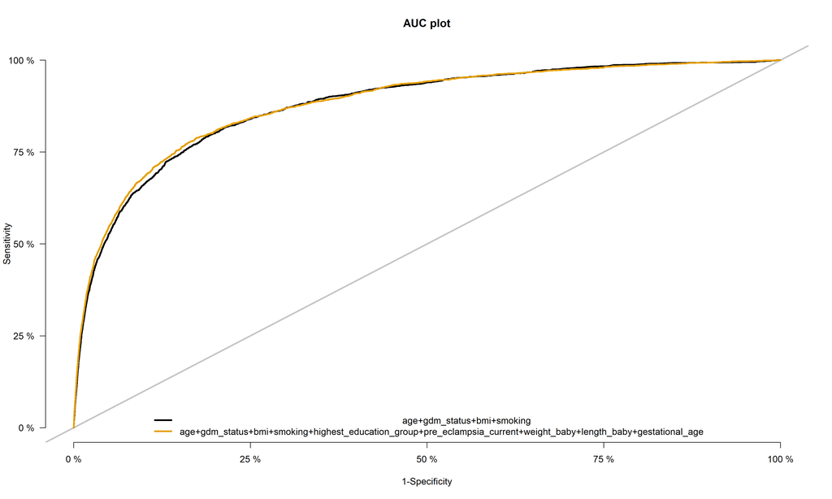

## Calibration

### Predicted versus observed 10-year risk

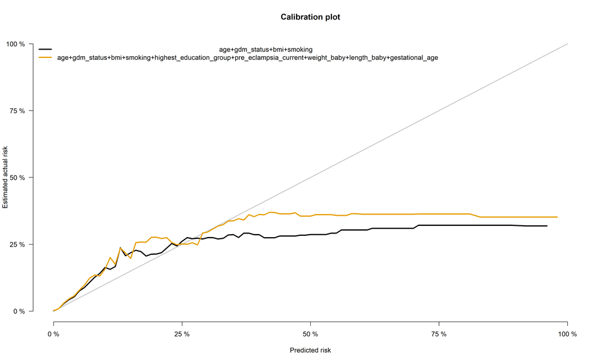

## Reach for WP4

SIMULATED EXAMPLE

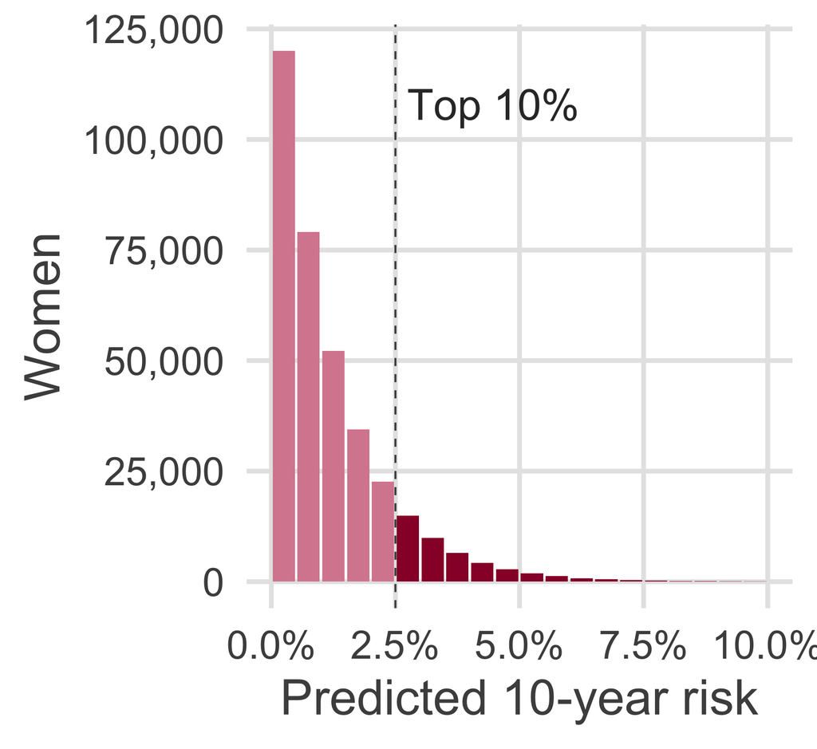

| Highest risk | Cases captured | PPV |
| --- | --- | --- |
| Top 5% | 45% | 13% |
| Top 10% | 60% | 9% |
| Top 20% | 75% | 6% |

**Cases captured:** share of all women who develop T2D within 10 years that are in the group

**PPV:** share of the group who develop T2D

## From model to WP4

### What WP4 could receive

**Final model**  
Retrain the best model on 2010-2015 and export from DST

**R Shiny app**  
10-year T2D risk and expected 5-year HbA1c, delivered to WP4

**Run on recent births**  
Distribution of risk, most informative data, geographical clustering

**WP4 focus group**  
e.g. GPs who measure HbA1c routinely in pregnancy; women above a BMI threshold

# Discussion

## Open questions

### For discussion today

1. **Optimism:** bootstrap correction on top of the regional and temporal test sets?
2. **Repeated births:** women contribute several births; split folds and test set by woman
3. **Censoring:** IPCW for the Brier score; death as a competing risk
4. **HbA1c:** indicator with calendar time, imputation or subcohort model?
5. **Region of origin:** WHO regions or the grouping in Nielsen et al. (JCEM 2024)?

## Open questions

### For discussion today

6. **Mode of delivery:** suggested categories: spontaneous vaginal, instrumental/assisted, planned c-section, emergency c-section- issues with identifying where data comes from
7. **Parity:** handled categorically, currently extreme values>6 regarded as missing (0.6% of population)
8. **History from previous pregnancies:** (for parity>1)- potential subset cohorts
9. **GDM/Pre-Eclampsia:** Defined diagnostic window early/normal/late - clinically useful?
10. **Newborn size:** SGA/LGA reference (Marsál 1996?); macrosomia at 4,000 or 4,500 g
11. **Explainability:** should WP4 see what drives a woman’s risk?

## Thank you

This work is supported by **DP-NEXT**

Questions and input for the protocol are very welcome

Co-authors of the protocol:

- Ulla Kampmann
- Daniel R. Witte
- Thomas Gerds
- Karoline Kragelund Nielsen
- Stine Byberg